# Capstone_EDA

Dan Powell

2025-02-14

# EDA

This section of our analysis focuses on the exploration of data through 3 steps - describing the data, cleaning the data, and exploring the data in-depth. First, before any of these steps, we must load in the data and packages we may use during EDA.

## Describe

Now, we want to describe the data. To do this we will first understand the structure and shape of each of our datasets.

### Transactional

The largest dataset is the transactional dataset, which we explore the size and shape here; as well as the kinds of variables the dataset holds.

```r
#look at structure and shape
cat('Number of rows and columns: ', dim(transactional_data_raw))
```

```
## Number of rows and columns:  1045540 11
```

```r
cat("\n Breakdown of columns:\n")
```

```
##
##  Breakdown of columns:
```

```r
str(transactional_data_raw)
```

```
## 'data.frame':    1045540 obs. of  11 variables:
##  $ TRANSACTION_DATE : chr  "1/5/2023" "1/6/2023" "1/9/2023" "1/11/2023" ...
##  $ WEEK             : int  1 1 2 2 3 4 4 4 4 5 ...
##  $ YEAR             : int  2023 2023 2023 2023 2023 2023 2023 2023 2023 2023 ...
##  $ CUSTOMER_NUMBER  : int  501202893 500264574 501174701 600586532 501014325 600567384 501363682 500245736 501100933 501372917 ...
##  $ ORDER_TYPE       : chr  "MYCOKE LEGACY" "MYCOKE LEGACY" "MYCOKE LEGACY" "SALES REP" ...
##  $ ORDERED_CASES    : num  1 12.5 2 18 29 1.5 6 0 4 18 ...
##  $ LOADED_CASES     : num  1 12.5 2 16 29 1.5 5 0 1 17 ...
##  $ DELIVERED_CASES  : num  1 12.5 2 16 29 1.5 5 0 1 17 ...
##  $ ORDERED_GALLONS  : num  90 0 0 2.5 0 0 0 25 0 0 ...
##  $ LOADED_GALLONS   : num  90 0 0 2.5 0 0 0 25 0 0 ...
##  $ DELIVERED_GALLONS: num  90 0 0 2.5 0 0 0 25 0 0 ...
```

We can deduce that this is ourl largest dataset due to over a million rows of data. Also contained within this dataset are metrics on gallons delivered, the order type, customer id, and the time of the delivery.

### Delivery Data

```r
#look at structure and shape
cat('Number of rows and columns: ', dim(delivery_data_raw))
```

```
## Number of rows and columns:  160 5
```

```r
cat("\n Breakdown of columns:\n")
```

```
##
##  Breakdown of columns:
```

```r
str(delivery_data_raw)
```

```
## 'data.frame':    160 obs. of  5 variables:
##  $ Cold.Drink.Channel  : chr  "WORKPLACE" "WORKPLACE" "WORKPLACE" "WORKPLACE" ...
##  $ Vol.Range           : chr  "0 - 149" "150 - 299" "300 - 449" "450 - 599" ...
##  $ Applicable.To       : chr  "Bottles and Cans" "Bottles and Cans" "Bottles and Cans" "Bottles and Cans" ...
##  $ Median.Delivery.Cost: chr  "$8.06" "$4.17" "$2.99" "$2.52" ...
##  $ Cost.Type           : chr  "Per Case" "Per Case" "Per Case" "Per Case" ...
```

```r
#look at structure and shape
cat('Number of rows and columns: ', dim(customer_profile_raw))
```

```
## Number of rows and columns:  30478 11
```

```r
cat("\n Breakdown of columns:\n")
```

```
##
##  Breakdown of columns:
```

```r
str(customer_profile_raw)
```

```
## 'data.frame':    30478 obs. of  11 variables:
##  $ CUSTOMER_NUMBER     : int  501556470 501363456 600075150 500823056 600082383 600079420 600080027 501382257 600076574 600076256 ...
##  $ PRIMARY_GROUP_NUMBER: int  376 NA 2158 2183 1892 NA 9996 NA NA 8803 ...
##  $ FREQUENT_ORDER_TYPE : chr  "MYCOKE LEGACY" "SALES REP" "SALES REP" "OTHER" ...
##  $ FIRST_DELIVERY_DATE : chr  "1/2/2024" "4/14/2022" "3/4/2016" "2/6/2019" ...
##  $ ON_BOARDING_DATE    : chr  "8/28/2023" "3/22/2022" "3/22/2012" "11/23/2018" ...
##  $ COLD_DRINK_CHANNEL  : chr  "DINING" "DINING" "DINING" "DINING" ...
##  $ TRADE_CHANNEL       : chr  "FAST CASUAL DINING" "COMPREHENSIVE DINING" "FAST CASUAL DINING" "FAST CASUAL DINING" ...
##  $ SUB_TRADE_CHANNEL   : chr  "PIZZA FAST FOOD" "FSR - MISC" "OTHER FAST FOOD" "ASIAN FAST FOOD" ...
##  $ LOCAL_MARKET_PARTNER: logi  TRUE TRUE TRUE FALSE TRUE TRUE ...
##  $ CO2_CUSTOMER        : logi  FALSE TRUE FALSE FALSE FALSE TRUE ...
##  $ ZIP_CODE            : int  21664 1885 67073 1885 1203 67952 40517 1568 41010 41010 ...
```

```r
#same for address and zip
cat('\n \nCustomer Addreess and Zip Info:\n')
```

```
##
##
## Customer Addreess and Zip Info:
```

```r
cat('Number of rows and columns: ', dim(customer_address_and_zip_raw))
```

```
## Number of rows and columns:  1801 2
```

```r
cat("\n Breakdown of columns:\n")
```

```
##
##  Breakdown of columns:
```

```r
str(customer_address_and_zip_raw)
```

```
## 'data.frame':    1801 obs. of  2 variables:
##  $ zip         : int  71018 71021 71023 71024 71039 71055 71058 71071 71072 71073 ...
##  $ full.address: chr  "71018,Cotton Valley,Louisiana,LA,Webster,119,32.819,-93.4259" "71021,Cullen,Louisiana,LA,Webster,119,32.9721,-93.4492" "71023,Doyline,Louisiana,LA,Webster,119,32.49,-93.3996" "71024,Dubberly,Louisiana,LA,Webster,119,32.5192,-93.2142" ...
```

The customer address and zip information seems to be a simple dataset just containing the customers zip code, along with their full address. This could be useful for geo-mapping. The more useful of the two customer datasets does seem to be the profile dataset. This contains information on the customer’s frequent order type, cold drink channel (which can be linked to connect delivery data to customers) and the customer’s id, which can be used to connect to our transaction data.

## Transformations

### Joining Datasets

```r
#see if zip is a primary key
cat('Zip Duplicated in address? ', any(duplicated(customer_address_and_zip_raw$zip)))
```

```
## Zip Duplicated in address?  FALSE
```

```r
#see if zip is foreign key
cat('Zip Duplicated in profile? ', any(duplicated(customer_profile_raw$zip)))
```

```
## Zip Duplicated in profile?  FALSE
```

```r
#join customer address to customer profile
customers_raw_joined <- left_join(customer_profile_raw, customer_address_and_zip_raw, by =c('ZIP_CODE' = 'zip'))

#customer joined with transactions
customers_trans_joined <- left_join(transactional_data_raw, customers_raw_joined, by ='CUSTOMER_NUMBER')
```

We will not be joining the delivery data as that dataset does not have an appropriate primary and foreign key. Despite the dataset sharing “Cold Drink Channel” - this is not an identifying / primary key column for delivery data to connect with our overarching dataset.

### Casting Data Types

Now that we have most of our data in a single dataset, let’s transform our chr variables into factors or other datatypes where appropriate.

```r
#get character columns
cust_tran_chr_cols <- names(customers_trans_joined)[sapply(customers_trans_joined, is.character)]
str(customers_trans_joined[cust_tran_chr_cols])
```

```
## 'data.frame':    1045540 obs. of  9 variables:
##  $ TRANSACTION_DATE   : chr  "1/5/2023" "1/6/2023" "1/9/2023" "1/11/2023" ...
##  $ ORDER_TYPE         : chr  "MYCOKE LEGACY" "MYCOKE LEGACY" "MYCOKE LEGACY" "SALES REP" ...
##  $ FREQUENT_ORDER_TYPE: chr  "SALES REP" "OTHER" "MYCOKE360" "SALES REP" ...
##  $ FIRST_DELIVERY_DATE: chr  "5/7/2021" "3/23/2018" "4/12/2021" "5/5/2017" ...
##  $ ON_BOARDING_DATE   : chr  "4/2/2021" "12/8/2015" "1/26/2021" "2/28/1997" ...
##  $ COLD_DRINK_CHANNEL : chr  "DINING" "WELLNESS" "DINING" "BULK TRADE" ...
##  $ TRADE_CHANNEL      : chr  "COMPREHENSIVE DINING" "HEALTHCARE" "FAST CASUAL DINING" "GENERAL" ...
##  $ SUB_TRADE_CHANNEL  : chr  "FSR - MISC" "OTHER HEALTHCARE" "OTHER FAST FOOD" "COMPREHENSIVE PROVIDER" ...
##  $ full.address       : chr  "66955,Mahaska,Kansas,KS,Washington,201,39.9845,-97.3453" "41603,Banner,Kentucky,KY,Floyd,71,37.5707,-82.6806" "01824,Chelmsford,Massachusetts,MA,Middlesex,17,42.5911,-71.3556" "01337,Bernardston,Massachusetts,MA,Franklin,11,42.6952,-72.5772" ...
```

```r
#convert dates to dates
date_columns_tran_cust <- c('TRANSACTION_DATE', 'FIRST_DELIVERY_DATE', 'ON_BOARDING_DATE')
customers_trans_joined_dates <- customers_trans_joined %>%
  mutate(across(all_of(date_columns_tran_cust), ~ case_when(
    TRUE ~ as.Date(., format = "%m/%d/%Y")
  )))
#convert remain chr to factors excluding full address
customers_trans_joined_factored <- customers_trans_joined_dates %>%
  mutate(across(where(is.character) & !matches("full.address"), as.factor))
#confirm factored and dates formatted
str(customers_trans_joined_factored)
```

```
## 'data.frame':    1045540 obs. of  22 variables:
##  $ TRANSACTION_DATE    : Date, format: "2023-01-05" "2023-01-06" ...
##  $ WEEK                : int  1 1 2 2 3 4 4 4 4 5 ...
##  $ YEAR                : int  2023 2023 2023 2023 2023 2023 2023 2023 2023 2023 ...
##  $ CUSTOMER_NUMBER     : int  501202893 500264574 501174701 600586532 501014325 600567384 501363682 500245736 501100933 501372917 ...
##  $ ORDER_TYPE          : Factor w/ 7 levels "CALL CENTER",..: 3 3 3 7 7 1 3 1 1 3 ...
##  $ ORDERED_CASES       : num  1 12.5 2 18 29 1.5 6 0 4 18 ...
##  $ LOADED_CASES        : num  1 12.5 2 16 29 1.5 5 0 1 17 ...
##  $ DELIVERED_CASES     : num  1 12.5 2 16 29 1.5 5 0 1 17 ...
##  $ ORDERED_GALLONS     : num  90 0 0 2.5 0 0 0 25 0 0 ...
##  $ LOADED_GALLONS      : num  90 0 0 2.5 0 0 0 25 0 0 ...
##  $ DELIVERED_GALLONS   : num  90 0 0 2.5 0 0 0 25 0 0 ...
##  $ PRIMARY_GROUP_NUMBER: int  NA 1894 NA 8397 1993 437 NA NA NA NA ...
##  $ FREQUENT_ORDER_TYPE : Factor w/ 6 levels "CALL CENTER",..: 6 5 4 6 6 6 6 5 6 6 ...
##  $ FIRST_DELIVERY_DATE : Date, format: "2021-05-07" "2018-03-23" ...
##  $ ON_BOARDING_DATE    : Date, format: "2021-04-02" "2015-12-08" ...
##  $ COLD_DRINK_CHANNEL  : Factor w/ 9 levels "ACCOMMODATION",..: 4 8 4 2 6 6 4 4 4 4 ...
##  $ TRADE_CHANNEL       : Factor w/ 26 levels "ACADEMIC INSTITUTION",..: 5 12 8 9 10 26 8 17 8 17 ...
##  $ SUB_TRADE_CHANNEL   : Factor w/ 48 levels "ASIAN FAST FOOD",..: 13 31 27 9 28 41 42 26 18 26 ...
##  $ LOCAL_MARKET_PARTNER: logi  TRUE TRUE TRUE FALSE TRUE TRUE ...
##  $ CO2_CUSTOMER        : logi  TRUE FALSE TRUE FALSE FALSE FALSE ...
##  $ ZIP_CODE            : int  66955 41603 1824 1337 67473 67060 21251 1420 40175 67364 ...
##  $ full.address        : chr  "66955,Mahaska,Kansas,KS,Washington,201,39.9845,-97.3453" "41603,Banner,Kentucky,KY,Floyd,71,37.5707,-82.6806" "01824,Chelmsford,Massachusetts,MA,Middlesex,17,42.5911,-71.3556" "01337,Bernardston,Massachusetts,MA,Franklin,11,42.6952,-72.5772" ...
```

```r
#get delivery character columns converted to factors
delivery_data_factored <- delivery_data_raw %>%
  mutate(across(where(is.character) & !matches("Median.Delivery.Cost"), as.factor))
#convert dollars to decimal for median delivery cost
delivery_data_factored$Median.Delivery.Cost <- as.numeric(gsub("[$,]", "", delivery_data_factored$Median.Delivery.Cost))
str(delivery_data_factored)
```

```
## 'data.frame':    160 obs. of  5 variables:
##  $ Cold.Drink.Channel  : Factor w/ 8 levels "ACCOMMODATION",..: 8 8 8 8 8 8 8 8 8 8 ...
##  $ Vol.Range           : Factor w/ 10 levels "0 - 149","1050 - 1199",..: 1 5 6 7 8 9 10 2 3 4 ...
##  $ Applicable.To       : Factor w/ 2 levels "Bottles and Cans",..: 1 1 1 1 1 1 1 1 1 1 ...
##  $ Median.Delivery.Cost: num  8.06 4.17 2.99 2.52 2.06 2 1.94 1.88 0.67 0.37 ...
##  $ Cost.Type           : Factor w/ 2 levels "Per Case","Per Gallon": 1 1 1 1 1 1 1 1 1 1 ...
```

### Null Columns

Now that we have our data in the appropriate data types, let’s look at null columns.

```r
#check delivery data for nulls
delivery_data_factored %>%
  summarize(across(everything(), ~sum(is.na(.)))) %>%
  print()
```

```
##   Cold.Drink.Channel Vol.Range Applicable.To Median.Delivery.Cost Cost.Type
## 1                  0         0             0                    0         0
```

```r
stg_delivery <- delivery_data_factored
#check tran_cust for nulls
customers_trans_joined_factored %>%
  summarize(across(everything(), ~sum(is.na(.)))) %>%
  print()
```

```
##   TRANSACTION_DATE WEEK YEAR CUSTOMER_NUMBER ORDER_TYPE ORDERED_CASES
## 1                0    0    0               0          0             0
##   LOADED_CASES DELIVERED_CASES ORDERED_GALLONS LOADED_GALLONS DELIVERED_GALLONS
## 1            0               0               0              0                 0
##   PRIMARY_GROUP_NUMBER FREQUENT_ORDER_TYPE FIRST_DELIVERY_DATE ON_BOARDING_DATE
## 1               490895                   0                   0                0
##   COLD_DRINK_CHANNEL TRADE_CHANNEL SUB_TRADE_CHANNEL LOCAL_MARKET_PARTNER
## 1                  0             0                 0                    0
##   CO2_CUSTOMER ZIP_CODE full.address
## 1            0        0            0
```

```r
#drop primary group number from cust_trans since it has nulls but and does not add information
stg_cust_tran <- subset(customers_trans_joined_factored, select = -PRIMARY_GROUP_NUMBER)
str(stg_cust_tran)
```

```
## 'data.frame':    1045540 obs. of  21 variables:
##  $ TRANSACTION_DATE    : Date, format: "2023-01-05" "2023-01-06" ...
##  $ WEEK                : int  1 1 2 2 3 4 4 4 4 5 ...
##  $ YEAR                : int  2023 2023 2023 2023 2023 2023 2023 2023 2023 2023 ...
##  $ CUSTOMER_NUMBER     : int  501202893 500264574 501174701 600586532 501014325 600567384 501363682 500245736 501100933 501372917 ...
##  $ ORDER_TYPE          : Factor w/ 7 levels "CALL CENTER",..: 3 3 3 7 7 1 3 1 1 3 ...
##  $ ORDERED_CASES       : num  1 12.5 2 18 29 1.5 6 0 4 18 ...
##  $ LOADED_CASES        : num  1 12.5 2 16 29 1.5 5 0 1 17 ...
##  $ DELIVERED_CASES     : num  1 12.5 2 16 29 1.5 5 0 1 17 ...
##  $ ORDERED_GALLONS     : num  90 0 0 2.5 0 0 0 25 0 0 ...
##  $ LOADED_GALLONS      : num  90 0 0 2.5 0 0 0 25 0 0 ...
##  $ DELIVERED_GALLONS   : num  90 0 0 2.5 0 0 0 25 0 0 ...
##  $ FREQUENT_ORDER_TYPE : Factor w/ 6 levels "CALL CENTER",..: 6 5 4 6 6 6 6 5 6 6 ...
##  $ FIRST_DELIVERY_DATE : Date, format: "2021-05-07" "2018-03-23" ...
##  $ ON_BOARDING_DATE    : Date, format: "2021-04-02" "2015-12-08" ...
##  $ COLD_DRINK_CHANNEL  : Factor w/ 9 levels "ACCOMMODATION",..: 4 8 4 2 6 6 4 4 4 4 ...
##  $ TRADE_CHANNEL       : Factor w/ 26 levels "ACADEMIC INSTITUTION",..: 5 12 8 9 10 26 8 17 8 17 ...
##  $ SUB_TRADE_CHANNEL   : Factor w/ 48 levels "ASIAN FAST FOOD",..: 13 31 27 9 28 41 42 26 18 26 ...
##  $ LOCAL_MARKET_PARTNER: logi  TRUE TRUE TRUE FALSE TRUE TRUE ...
##  $ CO2_CUSTOMER        : logi  TRUE FALSE TRUE FALSE FALSE FALSE ...
##  $ ZIP_CODE            : int  66955 41603 1824 1337 67473 67060 21251 1420 40175 67364 ...
##  $ full.address        : chr  "66955,Mahaska,Kansas,KS,Washington,201,39.9845,-97.3453" "41603,Banner,Kentucky,KY,Floyd,71,37.5707,-82.6806" "01824,Chelmsford,Massachusetts,MA,Middlesex,17,42.5911,-71.3556" "01337,Bernardston,Massachusetts,MA,Franklin,11,42.6952,-72.5772" ...
```

We only had one null column, PRIMARY_GROUP_NUMBER. Since this column does not seem to add information, we have decided to drop it.

### Eliminating Outliers

While we have many values in our numerical target variable, we are likely only interested in instances where gallons were ordered. Because of this, we will eliminate any 0 values in the target variable.

```r
cat('Before elimination of 0 observations: ', length(stg_cust_tran$ORDERED_GALLONS))
```

```
## Before elimination of 0 observations:  1045540
```

```r
stg_cust_tran <- stg_cust_tran[stg_cust_tran$ORDERED_GALLONS >= 1,]
cat('\n After elimination of 0 observations: ', length(stg_cust_tran$ORDERED_GALLONS))
```

```
##
##  After elimination of 0 observations:  479310
```

### Target Variables

We start our data exploration with the target variable. First, we create a box plot to observe the overall distribution along with some summary statistics of the variable.

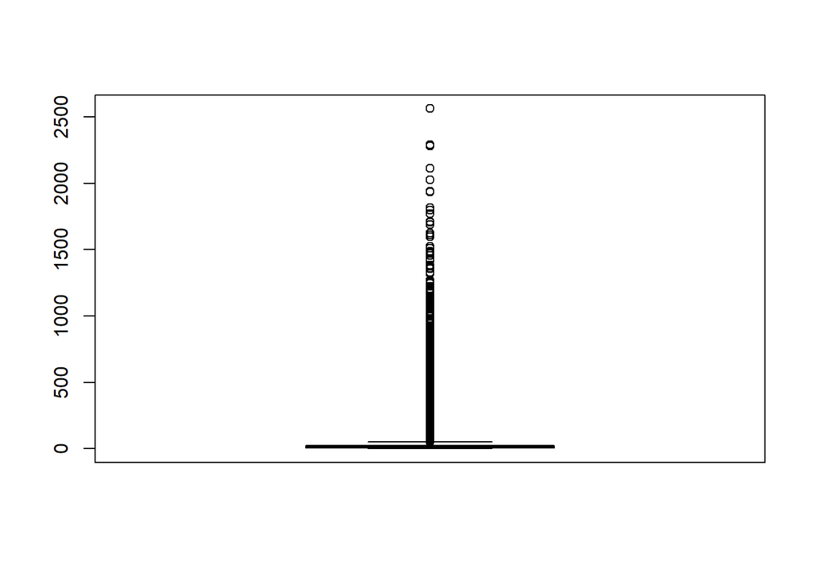

```r
boxplot(stg_cust_tran$ORDERED_GALLONS)
```

```r
summary(stg_cust_tran$ORDERED_GALLONS)
```

```
##    Min. 1st Qu.  Median    Mean 3rd Qu.    Max.
##    1.00    7.50   15.00   21.53   25.00 2562.50
```

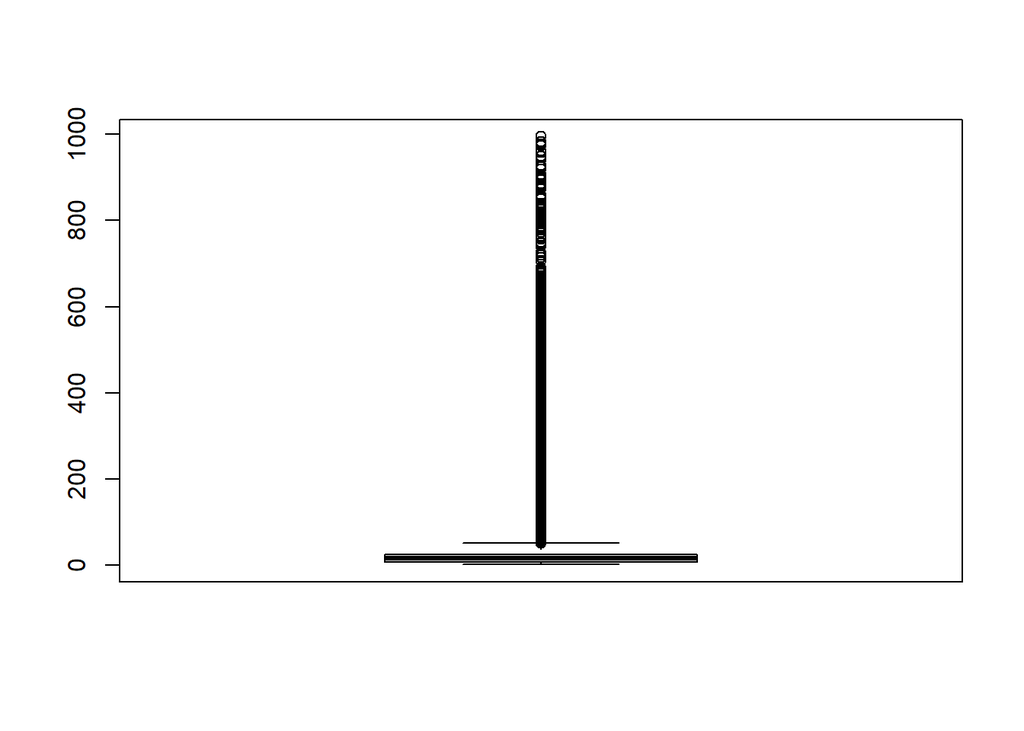

```r
stg_cust_tran <- stg_cust_tran[stg_cust_tran$ORDERED_GALLONS <= 1000,]
boxplot(stg_cust_tran$ORDERED_GALLONS)
```

### Categorical variables

To thin our dataset even further, we will take a look at our categorical variables to see which of them is most correlated with our target variable, ordered_gallons.

```r
#ANOVA test with factor variables
for (col in names(stg_cust_tran[, sapply(stg_cust_tran, is.factor)])) {
  anova_result <- aov(ORDERED_GALLONS ~ stg_cust_tran[[col]], data = stg_cust_tran)
  print(paste("ANOVA for", col, ":"))
  print(summary(anova_result)) # Look at the p-value
}
```

```
## [1] "ANOVA for ORDER_TYPE :"
##                          Df    Sum Sq Mean Sq F value Pr(>F)
## stg_cust_tran[[col]]      6   3104201  517367   523.2 <2e-16 ***
## Residuals            479234 473856753     989
## ---
## Signif. codes:  0 '***' 0.001 '**' 0.01 '*' 0.05 '.' 0.1 ' ' 1
## [1] "ANOVA for FREQUENT_ORDER_TYPE :"
##                          Df    Sum Sq Mean Sq F value Pr(>F)
## stg_cust_tran[[col]]      5    403401   80680   81.13 <2e-16 ***
## Residuals            479235 476557553     994
## ---
## Signif. codes:  0 '***' 0.001 '**' 0.01 '*' 0.05 '.' 0.1 ' ' 1
## [1] "ANOVA for COLD_DRINK_CHANNEL :"
##                          Df    Sum Sq Mean Sq F value Pr(>F)
## stg_cust_tran[[col]]      8  22074780 2759348    2907 <2e-16 ***
## Residuals            479232 454886174     949
## ---
## Signif. codes:  0 '***' 0.001 '**' 0.01 '*' 0.05 '.' 0.1 ' ' 1
## [1] "ANOVA for TRADE_CHANNEL :"
##                          Df    Sum Sq Mean Sq F value Pr(>F)
## stg_cust_tran[[col]]     24  50475669 2103153    2363 <2e-16 ***
## Residuals            479216 426485286     890
## ---
## Signif. codes:  0 '***' 0.001 '**' 0.01 '*' 0.05 '.' 0.1 ' ' 1
## [1] "ANOVA for SUB_TRADE_CHANNEL :"
##                          Df    Sum Sq Mean Sq F value Pr(>F)
## stg_cust_tran[[col]]     43  61959752 1440924    1664 <2e-16 ***
## Residuals            479197 415001202     866
## ---
## Signif. codes:  0 '***' 0.001 '**' 0.01 '*' 0.05 '.' 0.1 ' ' 1
```

From the ANOVA test of our categorical variables, we can see that there is a low P-Value for each of the variables. This means that there is a highly statistically significant difference between the groups in our factor columns. Because of this, we will one-hot encode all of them and then see which of the variables seems to be correlated with the target variable the most.

```r
names(stg_cust_tran[, sapply(stg_cust_tran, is.factor)])
```

```
## [1] "ORDER_TYPE"          "FREQUENT_ORDER_TYPE" "COLD_DRINK_CHANNEL"
## [4] "TRADE_CHANNEL"       "SUB_TRADE_CHANNEL"
```

```r
#one hot encoding
one_hot_data <- dummy_cols(stg_cust_tran, select_columns = c(names(stg_cust_tran[, sapply(stg_cust_tran, is.factor)])), remove_first_dummy = FALSE)
one_hot_data_isolated <-  one_hot_data[, c("ORDERED_GALLONS", names(one_hot_data)[(22+1):ncol(one_hot_data)])]
#get correlations
cor_matrix <- cor(one_hot_data_isolated[, -1], one_hot_data_isolated$ORDERED_GALLONS)
#convert to dataframe
cor_df <- as.data.frame(cor_matrix)
cor_df_ordered <- cor_df %>%
   mutate(across(everything(), round, 4)) %>%
  arrange(desc(abs(V1)))
print(cor_df_ordered)
```

```
##                                                    V1
## SUB_TRADE_CHANNEL_GAME CENTER                  0.2520
## TRADE_CHANNEL_ACTIVITIES                       0.2348
## COLD_DRINK_CHANNEL_EVENT                       0.1869
## SUB_TRADE_CHANNEL_BULK TRADE                   0.1480
## TRADE_CHANNEL_BULK TRADE                       0.1473
## COLD_DRINK_CHANNEL_DINING                     -0.1396
## SUB_TRADE_CHANNEL_RECREATION PARK              0.1170
## TRADE_CHANNEL_RECREATION                       0.1001
## COLD_DRINK_CHANNEL_BULK TRADE                  0.0795
## SUB_TRADE_CHANNEL_RECREATION FILM              0.0742
## TRADE_CHANNEL_LICENSED HOSPITALITY            -0.0696
## SUB_TRADE_CHANNEL_OTHER LICENSED HOSPITALITY  -0.0696
## TRADE_CHANNEL_ACADEMIC INSTITUTION             0.0593
## SUB_TRADE_CHANNEL_OTHER ACADEMIC INSTITUTION   0.0593
## TRADE_CHANNEL_COMPREHENSIVE DINING            -0.0518
## SUB_TRADE_CHANNEL_FSR - MISC                  -0.0518
## SUB_TRADE_CHANNEL_COMPREHENSIVE PROVIDER       0.0513
## TRADE_CHANNEL_GENERAL                          0.0507
## TRADE_CHANNEL_FAST CASUAL DINING              -0.0487
## SUB_TRADE_CHANNEL_OTHER TRAVEL                 0.0481
## TRADE_CHANNEL_TRAVEL                           0.0457
## SUB_TRADE_CHANNEL_BURGER FAST FOOD             0.0450
## ORDER_TYPE_SALES REP                           0.0449
## SUB_TRADE_CHANNEL_OTHER FAST FOOD             -0.0441
## TRADE_CHANNEL_PROFESSIONAL SERVICES           -0.0390
## SUB_TRADE_CHANNEL_OTHER PROFESSIONAL SERVICES -0.0390
## ORDER_TYPE_EDI                                 0.0383
## SUB_TRADE_CHANNEL_PIZZA FAST FOOD             -0.0364
## SUB_TRADE_CHANNEL_RECREATION ARENA             0.0334
## COLD_DRINK_CHANNEL_PUBLIC SECTOR               0.0331
## COLD_DRINK_CHANNEL_GOODS                      -0.0282
## SUB_TRADE_CHANNEL_MEXICAN FAST FOOD           -0.0252
## COLD_DRINK_CHANNEL_WELLNESS                   -0.0245
## TRADE_CHANNEL_HEALTHCARE                      -0.0244
## SUB_TRADE_CHANNEL_OTHER HEALTHCARE            -0.0244
## COLD_DRINK_CHANNEL_WORKPLACE                  -0.0216
## FREQUENT_ORDER_TYPE_CALL CENTER               -0.0211
## FREQUENT_ORDER_TYPE_SALES REP                  0.0209
## SUB_TRADE_CHANNEL_OTHER OUTDOOR ACTIVITIES     0.0199
```

[output cut: 41 more lines]

```
## SUB_TRADE_CHANNEL_HIGH SCHOOL                 -0.0022
## TRADE_CHANNEL_OTHER DINING & BEVERAGE         -0.0021
## SUB_TRADE_CHANNEL_OTHER DINING                -0.0021
## SUB_TRADE_CHANNEL_CHICKEN FAST FOOD           -0.0014
## SUB_TRADE_CHANNEL_CHAIN STORE                 -0.0007
## SUB_TRADE_CHANNEL_BULK BEVERAGE RETAIL         0.0004
## TRADE_CHANNEL_INDUSTRIAL                       0.0003
## SUB_TRADE_CHANNEL_OTHER INDUSTRIAL             0.0003
## SUB_TRADE_CHANNEL_RESIDENTIAL                 -0.0003
## SUB_TRADE_CHANNEL_HOME & HARDWARE              0.0002
## TRADE_CHANNEL_LARGE-SCALE RETAILER                 NA
## SUB_TRADE_CHANNEL_CLUB                             NA
## SUB_TRADE_CHANNEL_MIDDLE SCHOOL                    NA
## SUB_TRADE_CHANNEL_OTHER LARGE RETAILER             NA
## SUB_TRADE_CHANNEL_PRIMARY SCHOOL                   NA
```

Looking at our correlations of our target variable and the various factor columns, we can see that the top 10 variables hover around specific channels such as game centers, events, and activities. Now, we will see if any of these are highly correlated with each other to determine if there is room to remove variables that may be redundant.

```r
library(tidyr)
library(tibble)
#get binary columns
binary_cols <- names(one_hot_data_isolated)[names(one_hot_data_isolated) != "ORDERED_GALLONS"]
one_hot_binary <- one_hot_data_isolated[, binary_cols]

#get binary correlations and p-values
cor_matrix <- cor(one_hot_binary)
cor_df <- as.data.frame(cor_matrix)


cor_long <- cor_df %>%
  rownames_to_column(var = "variable1") %>%
  pivot_longer(cols = -variable1, names_to = "variable2", values_to = "correlation") %>%
  filter(variable1 != variable2)

cor_ordered <- cor_long %>%
  arrange(desc(abs(correlation)))

highly_correlated <- cor_ordered %>%
  filter(abs(correlation) > .7)

print(highly_correlated)
```

```
## # A tibble: 74 × 3
##    variable1                             variable2                   correlation
##    <chr>                                 <chr>                             <dbl>
##  1 COLD_DRINK_CHANNEL_CONVENTIONAL       TRADE_CHANNEL_PHARMACY RET…           1
##  2 COLD_DRINK_CHANNEL_CONVENTIONAL       SUB_TRADE_CHANNEL_INDEPEND…           1
##  3 TRADE_CHANNEL_ACCOMMODATION           SUB_TRADE_CHANNEL_OTHER AC…           1
##  4 TRADE_CHANNEL_COMPREHENSIVE DINING    SUB_TRADE_CHANNEL_FSR - MI…           1
##  5 TRADE_CHANNEL_DEFENSE                 SUB_TRADE_CHANNEL_OTHER MI…           1
##  6 TRADE_CHANNEL_GOURMET FOOD RETAILER   SUB_TRADE_CHANNEL_OTHER GO…           1
##  7 TRADE_CHANNEL_HEALTHCARE              SUB_TRADE_CHANNEL_OTHER HE…           1
##  8 TRADE_CHANNEL_INDUSTRIAL              SUB_TRADE_CHANNEL_OTHER IN…           1
##  9 TRADE_CHANNEL_LICENSED HOSPITALITY    SUB_TRADE_CHANNEL_OTHER LI…           1
## 10 TRADE_CHANNEL_OTHER DINING & BEVERAGE SUB_TRADE_CHANNEL_OTHER DI…           1
## # ℹ 64 more rows
```

From the dataframe showing highly correlated pairs, we will remove one of the pairs that are above a correlation of 0.7. This will result in shrinking our dataset to only binary columns that are significantly different from each other.

```r
#function to remove one of the two variables
remove_one_variable <- function(df, var1, var2) {
  if (var1 %in% names(df) && var2 %in% names(df)) { #Check if BOTH variables are still present
    # Check which variable has fewer missing values (prioritize keeping that one)
    na_count1 <- sum(is.na(df[[var1]]))
    na_count2 <- sum(is.na(df[[var2]]))

    var_to_remove <- ifelse(na_count1 > na_count2, var1, var2) #Remove the one with more NAs
    if(na_count1 == na_count2){ #If they are equal, default to var1.
      var_to_remove <- var1
    }

    df[[var_to_remove]] <- NULL  # Remove the selected variable from the original data frame
    print(paste("Removed variable:", var_to_remove)) #Print the name of the removed variable
  }
  return(df)
}

df_de_correlated <- one_hot_binary

for (i in 1:nrow(highly_correlated)) {
  var1 <- highly_correlated$variable1[i]
  var2 <- highly_correlated$variable2[i]

  # Check if the variable is still in the data frame before attempting removal
  if (var1 %in% names(df_de_correlated) && var2 %in% names(df_de_correlated)) {
    df_de_correlated <- remove_one_variable(df_de_correlated, var1, var2)
    #print(paste("Removed one of the variables:", var1, "or", var2))
  } else {
    #print(paste("One or both variables", var1, "and", var2, "were already removed."))
  }
}
```

```
## [1] "Removed variable: COLD_DRINK_CHANNEL_CONVENTIONAL"
## [1] "Removed variable: TRADE_CHANNEL_ACCOMMODATION"
## [1] "Removed variable: TRADE_CHANNEL_COMPREHENSIVE DINING"
## [1] "Removed variable: TRADE_CHANNEL_DEFENSE"
## [1] "Removed variable: TRADE_CHANNEL_GOURMET FOOD RETAILER"
## [1] "Removed variable: TRADE_CHANNEL_HEALTHCARE"
## [1] "Removed variable: TRADE_CHANNEL_INDUSTRIAL"
## [1] "Removed variable: TRADE_CHANNEL_LICENSED HOSPITALITY"
## [1] "Removed variable: TRADE_CHANNEL_OTHER DINING & BEVERAGE"
## [1] "Removed variable: TRADE_CHANNEL_PHARMACY RETAILER"
## [1] "Removed variable: TRADE_CHANNEL_SPECIALIZED GOODS"
## [1] "Removed variable: TRADE_CHANNEL_PROFESSIONAL SERVICES"
## [1] "Removed variable: TRADE_CHANNEL_PUBLIC SECTOR (NON-MILITARY)"
## [1] "Removed variable: TRADE_CHANNEL_ACADEMIC INSTITUTION"
## [1] "Removed variable: TRADE_CHANNEL_MOBILE RETAIL"
```

[output cut: 16 more lines]

```r
cat('Variables kept: ', names(df_de_correlated))
```

```
## Variables kept:  ORDER_TYPE_EDI ORDER_TYPE_MYCOKE LEGACY ORDER_TYPE_MYCOKE360 ORDER_TYPE_null ORDER_TYPE_OTHER ORDER_TYPE_SALES REP FREQUENT_ORDER_TYPE_CALL CENTER FREQUENT_ORDER_TYPE_EDI FREQUENT_ORDER_TYPE_MYCOKE LEGACY FREQUENT_ORDER_TYPE_MYCOKE360 FREQUENT_ORDER_TYPE_SALES REP COLD_DRINK_CHAN…
```

```r
stg_one_hot_data <- cbind(one_hot_data[, 1:22], one_hot_data[, names(df_de_correlated)])
```

### Numerical Variables

Now we move onto the numerical variables in our data. Here we will look to see if there is any relationship between the other numerical columns and the target variable of ordered.

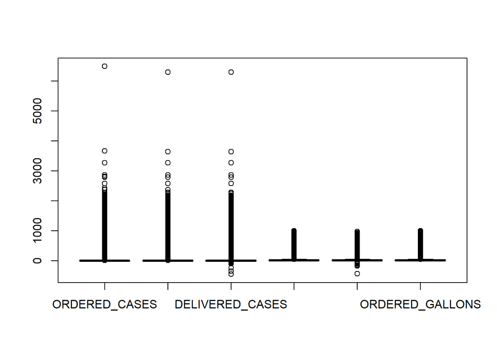

```r
numerical_df <- stg_one_hot_data[, c('ORDERED_CASES', 'LOADED_CASES', 'DELIVERED_CASES',
                                  'LOADED_GALLONS','DELIVERED_GALLONS','ORDERED_GALLONS')]
#create copy for transformation
numerical_df_filtered <- numerical_df
#Check for outliers
boxplot(numerical_df)
```

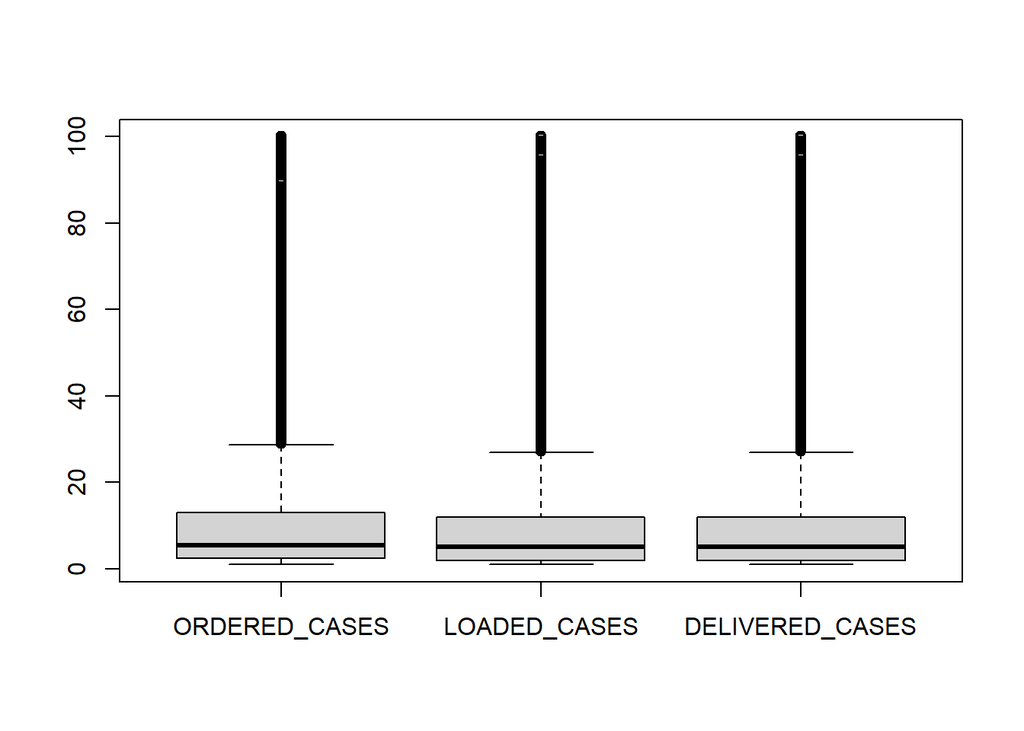

```r
#eliminate case observations above 100 in dataset to see mean distirbution closer
numerical_df_filtered <- numerical_df_filtered[(
              (numerical_df_filtered$ORDERED_CASES <= 100)
                                & (numerical_df_filtered$LOADED_CASES <= 100)
                               & (numerical_df_filtered$DELIVERED_CASES <= 100)
                              & (numerical_df_filtered$LOADED_GALLONS <= 100)
                             & (numerical_df_filtered$DELIVERED_GALLONS <= 100)),]

#redisplay box plot
boxplot(numerical_df)
#eliminate negative numbers and zero values
numerical_df_filtered <- numerical_df_filtered %>%
  filter(!if_any(all_of(c('ORDERED_CASES', 'LOADED_CASES', 'DELIVERED_CASES',
                       'LOADED_GALLONS','DELIVERED_GALLONS')), ~. < 1))

boxplot(numerical_df_filtered[,c('ORDERED_CASES', 'LOADED_CASES', 'DELIVERED_CASES'
                       )])
```

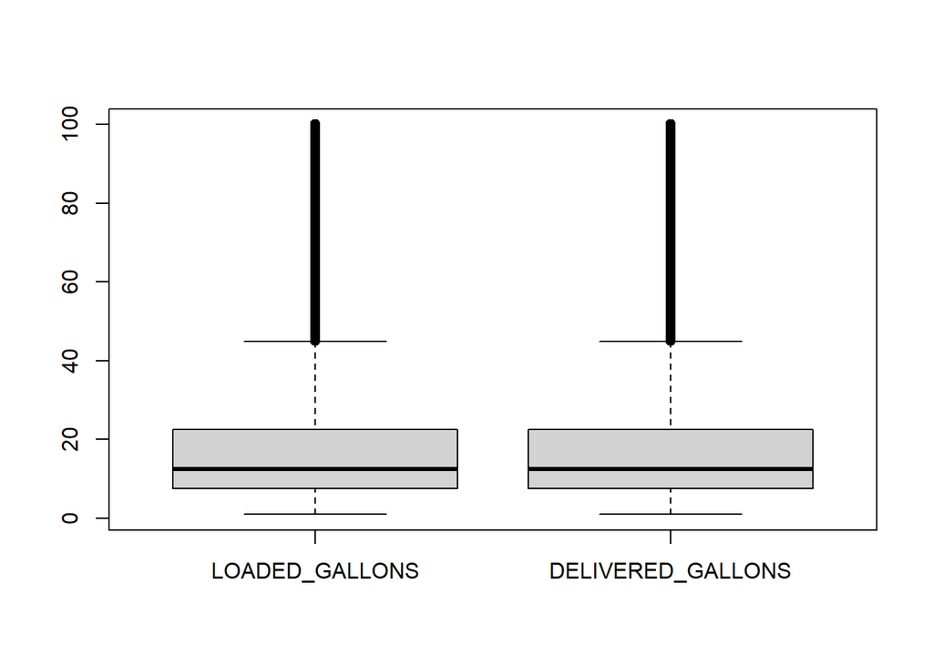

```r
boxplot(numerical_df_filtered[,c('LOADED_GALLONS','DELIVERED_GALLONS')
                       ])
```

```r
#get correlations
cor_matrix <- cor(numerical_df_filtered, numerical_df_filtered$ORDERED_GALLONS)
#convert to dataframe
cor_df <- as.data.frame(cor_matrix)
cor_df_ordered <- cor_df %>%
  arrange(desc(abs(V1)))
print(cor_df_ordered)
```

```
##                           V1
## ORDERED_GALLONS   1.00000000
## LOADED_GALLONS    0.98178998
## DELIVERED_GALLONS 0.97698934
## LOADED_CASES      0.07658089
## DELIVERED_CASES   0.07616042
## ORDERED_CASES     0.07540664
```

```r
numerical_df_filtered$order_delivery_delta <- numerical_df_filtered$DELIVERED_CASES - numerical_df_filtered$ORDERED_CASES
#summary of values
summary(numerical_df_filtered$order_delivery_delta)
```

```
##     Min.  1st Qu.   Median     Mean  3rd Qu.     Max.
## -88.0000   0.0000   0.0000  -0.6542   0.0000  57.0000
```

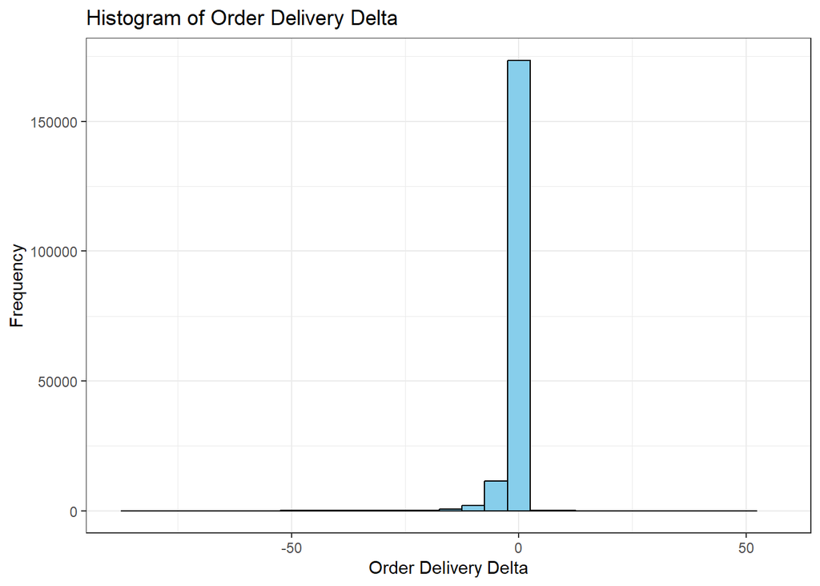

```r
#make historgram
ggplot(numerical_df_filtered, aes(x = numerical_df_filtered$order_delivery_delta)) +
  geom_histogram(bins = 30,  # Or adjust binwidth as needed
                 fill = "skyblue",
                 color = "black") +
  labs(title = "Histogram of Order Delivery Delta",
       x = "Order Delivery Delta",
       y = "Frequency") +
  theme_bw() +
  scale_x_continuous(limits = c(min(numerical_df_filtered$order_delivery_delta), max(numerical_df_filtered$order_delivery_delta)))
```

We can see from the histogram that we tend to under-deliver for customers rather than over-deliver This could be due to damages along the deliver route or spoiled product. While not exactly related to the question at hand, this could rise a new study to investigate “under-deliveries” to ensure customers receive what they ordered more often. Before moving on, we will apply our filters to the overall data to maintain our assumptions.

```r
#make copy
stg_w_numerical <- stg_one_hot_data
#rid of 0 and negative
stg_w_numerical <- stg_w_numerical %>%
  filter(!if_any(all_of(c('ORDERED_CASES', 'LOADED_CASES', 'DELIVERED_CASES',
                       'LOADED_GALLONS','DELIVERED_GALLONS')), ~. < 1))
#limit observations to under 1000 since we want to keep observations around 400 still
stg_w_numerical <- stg_w_numerical[(
              (stg_w_numerical$ORDERED_CASES <= 1000)
                                & (stg_w_numerical$LOADED_CASES <= 1000)
                               & (stg_w_numerical$DELIVERED_CASES <= 1000)
                              & (stg_w_numerical$LOADED_GALLONS <= 1000)
                             & (stg_w_numerical$DELIVERED_GALLONS <= 1000)),]

summary(stg_w_numerical[, c('ORDERED_CASES', 'LOADED_CASES', 'DELIVERED_CASES',
                       'LOADED_GALLONS','DELIVERED_GALLONS')])
```

```
##  ORDERED_CASES     LOADED_CASES    DELIVERED_CASES  LOADED_GALLONS
##  Min.   :  1.00   Min.   :  1.00   Min.   :  1.00   Min.   :  1.00
##  1st Qu.:  3.00   1st Qu.:  2.50   1st Qu.:  2.00   1st Qu.:  7.50
##  Median :  6.00   Median :  6.00   Median :  5.50   Median : 15.00
##  Mean   : 21.17   Mean   : 20.34   Mean   : 20.11   Mean   : 23.55
##  3rd Qu.: 15.00   3rd Qu.: 14.50   3rd Qu.: 14.25   3rd Qu.: 25.00
##  Max.   :996.00   Max.   :998.00   Max.   :976.00   Max.   :993.49
##  DELIVERED_GALLONS
##  Min.   :  1.00
##  1st Qu.:  7.50
##  Median : 15.00
##  Mean   : 23.21
##  3rd Qu.: 25.00
##  Max.   :975.00
```

### Binary Variables

The final variable type of interest is our two binary variables - LOCAL MARKET PARTNER and CO2_CUSTOMER. We’ll do a simple correlation analysis to see if either of these are strongly correlated with the target variable.

```r
#transform to binary
stg_w_numerical$LOCAL_MARKET_PARTNER <- ifelse(stg_w_numerical$LOCAL_MARKET_PARTNER == TRUE, 1, 0)
stg_w_numerical$CO2_CUSTOMER <- ifelse(stg_w_numerical$CO2_CUSTOMER == TRUE, 1, 0)
#select binary columns and target variable
binary_df <- stg_w_numerical %>%
  select(CO2_CUSTOMER, LOCAL_MARKET_PARTNER, ORDERED_GALLONS)
#create correlation matrix and sort for display
#get correlations
cor_matrix <- cor(binary_df, binary_df$ORDERED_GALLONS)
#convert to dataframe
cor_df <- as.data.frame(cor_matrix)
cor_df_ordered <- cor_df %>%
  arrange(desc(abs(V1)))
print(cor_df_ordered)
```

```
##                              V1
## ORDERED_GALLONS       1.0000000
## LOCAL_MARKET_PARTNER -0.1936766
## CO2_CUSTOMER         -0.1255529
```

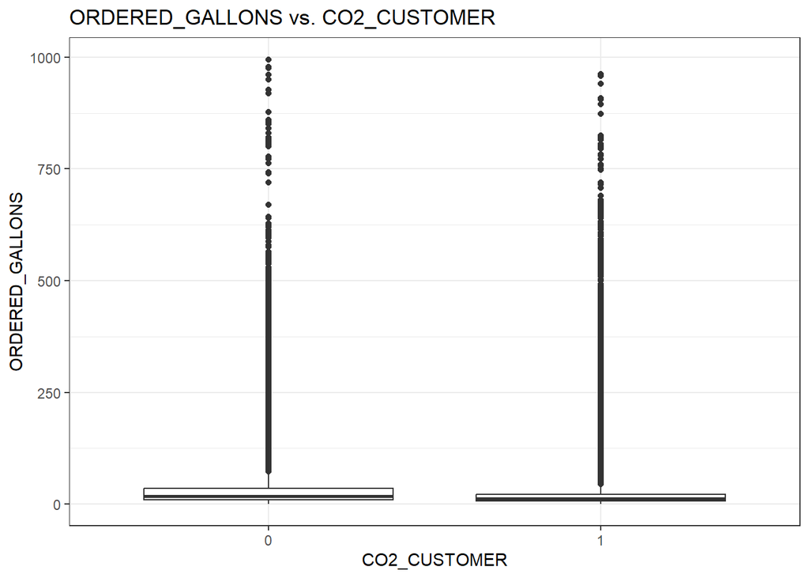

```r
#boxplot for target variables
binary_df$LOCAL_MARKET_PARTNER <- as.factor(binary_df$LOCAL_MARKET_PARTNER)
binary_df$CO2_CUSTOMER <- as.factor(binary_df$CO2_CUSTOMER)

ggplot(binary_df, aes(x = CO2_CUSTOMER, y = ORDERED_GALLONS)) +
  geom_boxplot() +
  labs(title = "ORDERED_GALLONS vs. CO2_CUSTOMER",
       x = "CO2_CUSTOMER",
       y = "ORDERED_GALLONS") +
  theme_bw()
```

It seems that non-CO2 customers tend to order more gallons on average than CO2 customers in cases where at least one gallon is ordered.

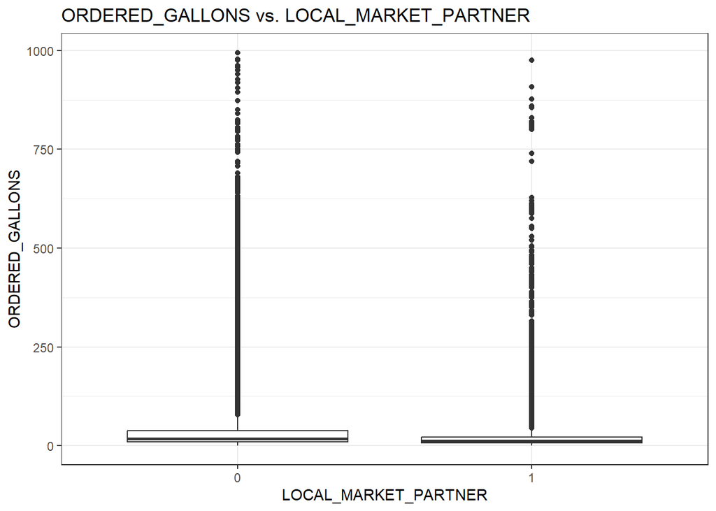

```r
ggplot(binary_df, aes(x = LOCAL_MARKET_PARTNER, y = ORDERED_GALLONS)) +
  geom_boxplot() +
  labs(title = "ORDERED_GALLONS vs. LOCAL_MARKET_PARTNER",
       x = "LOCAL_MARKET_PARTNER",
       y = "ORDERED_GALLONS") +
  theme_bw()
```

The same appears true for local market partner - with those not being a local market partner seemingly having a higher overall distribution of ordered gallons.

## Time Analysis

```r
library(forecast)
library(tseries)
library(astsa)
library(lubridate)
library(zoo)
time_analysis_df <- stg_w_numerical[,c('ORDERED_GALLONS', 'TRANSACTION_DATE')]
#group  into mean sales per day
time_analysis_df <- time_analysis_df %>%
  group_by(TRANSACTION_DATE) %>%
  summarize(
    mean_ordered_gallons = median(ORDERED_GALLONS)
  )
#see if data is stationary
time_analysis_ts <- zoo(time_analysis_df$mean_ordered_gallons, order.by = time_analysis_df$TRANSACTION_DATE)
time_analysis_ts <- aggregate(time_analysis_ts, as.Date(cut(index(time_analysis_ts), "week")), tail, 1)

#conduct ADS test on stationary data
adfTest <- adf.test(time_analysis_ts, alternative = 'stationary')
adfTestPValue <- adfTest$p.value
cat('P-Value of Dickey-Fuller test is', round(adfTestPValue,4))
```

```
## P-Value of Dickey-Fuller test is 0.0381
```

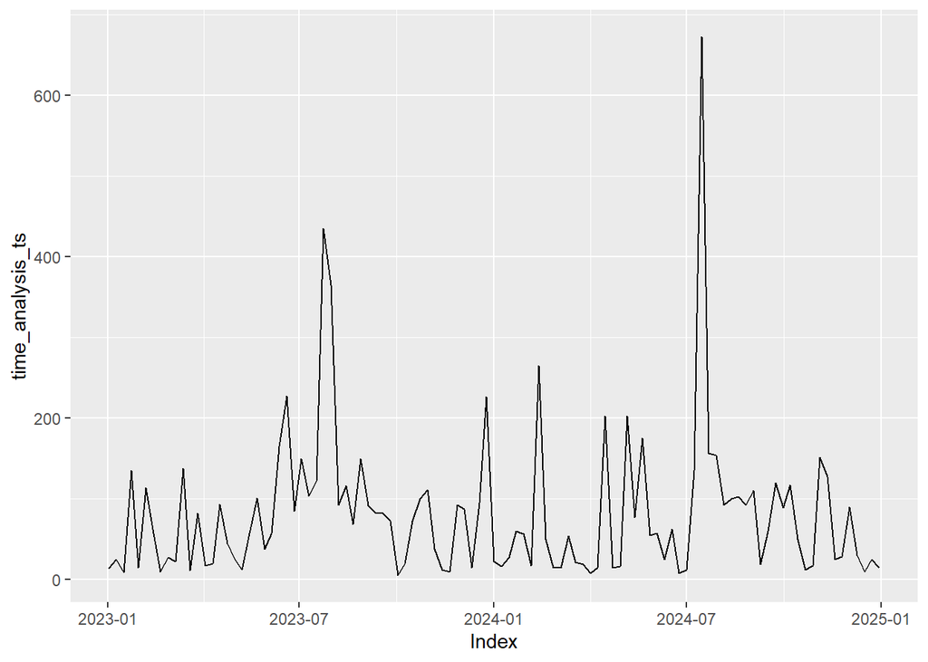

```r
#create plot
autoplot(time_analysis_ts)
```

# Summary of EDA

Our EDA discovered a few interesting findings. First, the channels and sub channels within the categorical variables seem promising for indicators, especially those surrounding activities, game centers, and events. We also noticed 0 gallons ordered records in the raw data and outliers above 1000 gallons ordered that may have skewed our observations. We also found that our two original binary variables for CO2 customers and Local market customers both seemed to be negatively correlated with the target variable. Finally, it seems that the characteristics of the customer impact gallons ordered that cannot be attributed to time alone. Our final dataset now looks as follows:

```r
summary(stg_w_numerical)
```

```
##  TRANSACTION_DATE          WEEK            YEAR      CUSTOMER_NUMBER
##  Min.   :2023-01-03   Min.   : 1.00   Min.   :2023   Min.   :500245678
##  1st Qu.:2023-07-18   1st Qu.:15.00   1st Qu.:2023   1st Qu.:501091646
##  Median :2024-01-24   Median :27.00   Median :2024   Median :501538801
##  Mean   :2024-01-12   Mean   :26.83   Mean   :2024   Mean   :546205888
##  3rd Qu.:2024-07-12   3rd Qu.:39.00   3rd Qu.:2024   3rd Qu.:600079614
##  Max.   :2024-12-31   Max.   :52.00   Max.   :2024   Max.   :600975408
##
##          ORDER_TYPE    ORDERED_CASES     LOADED_CASES    DELIVERED_CASES
##  CALL CENTER  :47477   Min.   :  1.00   Min.   :  1.00   Min.   :  1.00
##  EDI          :  960   1st Qu.:  3.00   1st Qu.:  2.50   1st Qu.:  2.00
##  MYCOKE LEGACY:62119   Median :  6.00   Median :  6.00   Median :  5.50
##  MYCOKE360    :20964   Mean   : 21.17   Mean   : 20.34   Mean   : 20.11
##  null         :  106   3rd Qu.: 15.00   3rd Qu.: 14.50   3rd Qu.: 14.25
##  OTHER        : 1410   Max.   :996.00   Max.   :998.00   Max.   :976.00
##  SALES REP    :66575
##  ORDERED_GALLONS  LOADED_GALLONS   DELIVERED_GALLONS    FREQUENT_ORDER_TYPE
##  Min.   :  1.00   Min.   :  1.00   Min.   :  1.00    CALL CENTER  :  1824
##  1st Qu.:  7.50   1st Qu.:  7.50   1st Qu.:  7.50    EDI          :    76
##  Median : 15.00   Median : 15.00   Median : 15.00    MYCOKE LEGACY:   615
##  Mean   : 24.27   Mean   : 23.55   Mean   : 23.21    MYCOKE360    :  5825
##  3rd Qu.: 25.00   3rd Qu.: 25.00   3rd Qu.: 25.00    OTHER        : 29581
##  Max.   :994.70   Max.   :993.49   Max.   :975.00    SALES REP    :161690
##
##  FIRST_DELIVERY_DATE  ON_BOARDING_DATE         COLD_DRINK_CHANNEL
##  Min.   :2015-11-30   Min.   :1981-08-01   DINING       :127193
##  1st Qu.:2017-04-10   1st Qu.:2009-09-09   EVENT        : 30570
##  Median :2018-05-01   Median :2017-01-24   BULK TRADE   : 14465
##  Mean   :2019-03-23   Mean   :2013-12-26   WELLNESS     :  8655
##  3rd Qu.:2021-04-26   3rd Qu.:2021-02-10   ACCOMMODATION:  6857
##  Max.   :2024-12-30   Max.   :2024-12-19   PUBLIC SECTOR:  5354
##                                            (Other)      :  6517
##                  TRADE_CHANNEL                  SUB_TRADE_CHANNEL
##  FAST CASUAL DINING     :56462   FSR - MISC              :40957
##  COMPREHENSIVE DINING   :40957   OTHER DINING            :23764
##  OTHER DINING & BEVERAGE:23764   MEXICAN FAST FOOD       :23153
##  OUTDOOR ACTIVITIES     :19112   OTHER OUTDOOR ACTIVITIES:18838
##  GENERAL                :14019   COMPREHENSIVE PROVIDER  :14010
##  HEALTHCARE             : 8655   OTHER FAST FOOD         :13598
##  (Other)                :36642   (Other)                 :65291
```

[output cut: 257 more lines]

```
##  Min.   :0.000000                  Min.   :0.0000000
##  1st Qu.:0.000000                  1st Qu.:0.0000000
##  Median :0.000000                  Median :0.0000000
##  Mean   :0.001538                  Mean   :0.0003457
##  3rd Qu.:0.000000                  3rd Qu.:0.0000000
##  Max.   :1.000000                  Max.   :1.0000000
##
##  SUB_TRADE_CHANNEL_SANDWICH FAST FOOD
##  Min.   :0.000000
##  1st Qu.:0.000000
##  Median :0.000000
##  Mean   :0.008216
##  3rd Qu.:0.000000
##  Max.   :1.000000
##
```